# Point Pattern Analysis Methods for Health Data

# 3 Point pattern methods

Many method grouping schemas exist in different texts. Some grouped by sampling method (population data-sample data<sup>2</sup>). While, some others grouped by a sequence of analytic approach: preliminary testing-descriptive statistics-modeling<sup>3</sup>. The latter is, perhaps, more effective from a user perspective as methods could be capable of handling mulitiple data types but are almost always designed for a particular analytic objective. This paper will simplify the sequential schema, in plain language, into three stages: identifying, describing, and explaining the pattern. Classic methods (not exhaustive) will then be categorized by the stage which fits their output. Summaries of methods’ objectives, theory basis, assumptions, and limitations will be given, along with R code examples.

## 3.1 Identifying patterns

In this stage, the location of the points is of primary interest, rather than attributes associated with the points. The goal is to differentiate between random patterns and cluster/disperse patterns. Methods in this category usually compute a test statistic from the data and compare it to an expected value for a theoretical random pattern (a.k.a., Complete Spatial Randomness or Poisson point process).

### 3.1.1 Diggle’s Refined Nearest Neighbour Analysis (completed up to here)

#### 3.1.1.1 Summary<sup>2,4</sup>

- Objective: Test for Complete Spatial Randomness (CSR)
  - $H_0$: The point pattern is random.
  - $H_1$: The pattern is not random. The sign of the test statitstic indicates clustering (-) or dispersion (+).
- Prerequisites: The data is **a complete census of all events** in the study area, and the events are located independently.
- Description:
  - This method is based on the nearest neighbour distance (NND). It requires the user to specify a range of distance $w$, and the number of bins (e.g., every 10 meters from 10 to 100 meters).
  - For each specified distance $w_i$, the proportion of points that nnd is less than $w_i$ is denoted as a function $G(w)=\frac{n \mid _{nnd \le w_{i}}}{N-n_{edge}}$. The $G$ function is an approximation of the distribution function of NND. Note that the points ($n_{edge}$) that are close to the boundary (i.e., the distance between the point and the nearest boundary is less than $w_i$) are excluded from the proportion calculation (visually equal to shrink the study area inward by $w_i$). Thus, **edge correction is not required** .
  - Under CSR, the theoretical value for G is $E[G(w_i)]=1-e^{-\lambda\pi w_{i}^{2}}$, where $\lambda$ is the point intensity within the study area. Then, a test statistic $d_w$ can be calculate by the maximum difference between the theoretical and observed $G$s over the range of $w$: $d_w=max|E[G(w)]-G(w)|$
  - Monte Carlo simulation can evaluate the test statistic. $d_w$s can be computed from $n$ simulated patterns. The p-value is the probability of having simulated $d_w$ more extreme than the one from the data: $p = \frac{n \mid _{d_{sim}>d_{obs}}+1}{n+1}$
  - This method has two other variations. The $G$ function uses NND between two events. One variation, the $F$ function can be computed in the same way as $G$ but using NND between one point in an arbitrary grid and an event. The test statistic $d_w$ calculated based on the $G$ is more effective against clustering, while its counterpart using $F$ is more effective against dispersion. $d_w=max|F(w)-G(w)|$ is another variation, which performs as a compromise between the other two in terms of effectiveness.
- Limitation: The result is a single number for the entire area, which implies that the process of interest needs to be stationary over the study area.

#### 3.1.1.2 Example

Assume that the synthetic dataset was all illegal drug overdose cases in Vancouver in 2018. We want to know whether the cases are randomly distributed. If the pattern is not random, further investigations are required.

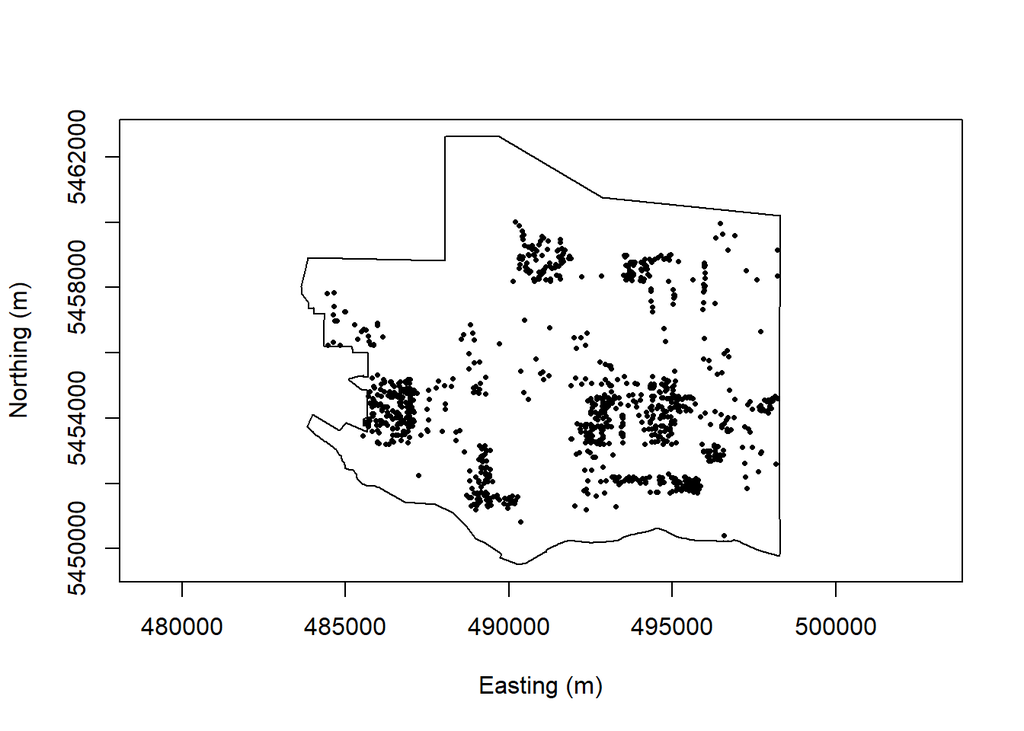

Figure 2. The synthetic data is transformed and plot in UTM zone 10 projections for distance calculations in meter. In this example for refined nearest neighbour analysis, the points are assumed to be all illegal drug overdose cases in Vancouver in 2018.

```r
#load required package
require("splancs")

#transfrom the points and Vancouver boundary polygon into UTM zone 10 projection for distance calculation in meters
pts_utm <- st_transform(pts, "+proj=utm +zone=10 +datum=WGS84 +units=m")
van_poly_utm <- st_transform(van_poly, "+proj=utm +zone=10 +datum=WGS84 +units=m")
#extract coordinates from the two layers as separate dataframes
pts_rnna <- as.points(st_coordinates(pts_utm)[,c(1,2)])
poly_rnna <- as.points(st_coordinates(van_poly_utm)[,c(1,2)])
#plot the data in UTM coordinates
polymap(poly_rnna, ylab = "Northing (m)", xlab = "Easting (m)")
pointmap(pts_rnna, pch = 16, cex = 0.5, add = T)
```

Firstly, we need to define the range for $w$. Let’s calucate the NNDs between every pair of points and get the summary statistics:

```r
#calculate and sumarize all NNDs
nndist_pts <- as.data.frame(nndistG(pts_rnna))
summary(nndist_pts$dists)
```

```
##     Min.  1st Qu.   Median     Mean  3rd Qu.     Max.
##    7.822   44.528   67.584   99.622  106.210 1541.242
```

A range from 5 to 1550 m is suffix to reproduce the entire NND distribution.

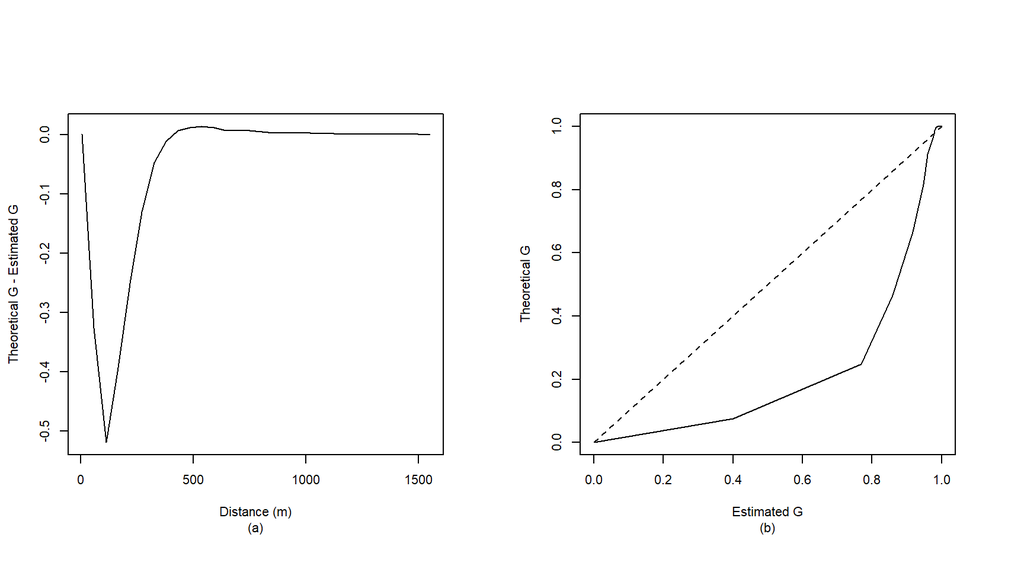

Figure 3. (a) Departure from complete spatial randomness over the specified distance range. The sign of y-aix indicates clustering (-) or dispersion (+). (b) A visualization highlighting the magnitude of departure from complete spatial randomness (CSR). The dash line represents the G function under CSR, whilt the solid line is the G function calculated from the data.

```r
#create a sequence of distances w
w <- seq(5,1550,length=30)
#calculate the observed G(w)
g_est <- Ghat(pts_rnna,w)
#calculate the theorectical G(w)
g_expect <- Fzero(pdense(pts_rnna,poly_rnna), w)
#compute the test statistic dw
d_w <- max(abs(g_expect-g_est))
#plot graphs for interpretation of result
par(mfrow=c(1,2),mai=c(1.0,0.6,1.0,0.6),cex=0.7)
plot(w,g_expect-g_est, type = "l", ylab = "Theoretical G - Estimated G", xlab = "Distance (m)", sub = "(a)")
plot(g_est, g_expect, type = "l", ylab = "Theoretical G", xlab = "Estimated G", sub = "(b)")
lines(c(0,1), c(0,1), lty = 2)
```

In Figure 3, it can be observed that the data greatly departs from CSR in both figures, and, in (a), the pattern is highly clustered within 100 m radius of each point. We can not conclude whether the departure is statistically significant at this point. Let’s calculate a p-value using Monte Carlo simulation:

```r
#Monte Carlo simulation for 1000 runs
for (i in 1000) {
  pts_sim <- csr(poly_rnna, npts(pts_rnna)) #generate a n-point CSR pattern within the boundary
  #compute the test statistic dw
  g_sim <- Ghat(pts_sim, w)
  g_exp_sim <- Fzero(pdense(pts_sim,poly_rnna),w)
  d_sim <- max(abs(g_exp_sim-g_sim))
  d_w <- c(d_w,d_sim) #the first element in the list d_w is the one for the data
}
#compute the p-value
p <- rank(d_w)[1]/(1000+1)
p
```

```
## [1] 0.001998002
```

### 3.1.2 Ripley’s K

## 3.2 Describing patterns

### 3.2.1 Global and local Moran’s I

### 3.2.2 Variogram

### 3.2.3 Kernal density estimation

#### 3.2.3.1 Summary<sup>5</sup>

- Objective: to display the spatial distribution of points for visual check of hot spots
- Prerequisites: The events are independent of each other, but the point process’s probability intensity varies over space.
- Description:
  - KDE estimates a random 2D point process’s probability density function f(x,y). $\hat{f}(x,y)=\frac{1}{nh_{x}h{_y}}\sum_ik(\frac{x-x_{i}}{h_{x}},\frac{y-y_{i}}{h_{y}})$
  - It is essentially a smoothing technique that superimposes a ‘kernel’ (a function in a certain shape, e.g., bell shape Gaussian kernel) at each point, then sums and averages the overlapping/stacking kernels of the neighboring points.
  - The extent of the neighboring points is determined by two bandwidth parameters ($h_{x}, h_{y}$) specified by the user. If the bandwidths are too narrow, the resulting probability intensity surface would have spikes at each point. In contrast, the surface could be overly smoothed or flatten if the bandwidths are too wide.
  - According to the KDE equation given above, there is no stochastic component, and the result is straightly computed from the observed data. Therefore, KDE is more of a data visualization technique, rather than sophisticated statistical modeling of the point process.
- Limitation: It is obvious that the result greatly depends on the arbitrarily chosen bandwidths. A simple rule proposed by Bowman and Azzalini (1997) and Scott (1992): $h_{x}=\sigma_{x}(\frac{2}{3n})^{\frac{1}{6}}$, where$\sigma_{x}$ is the standard deviation of the x, and $h_{y}$ can be computed in the same way if there is no strong direction effect in the target process. There are also more sophisticated algorithms, e.g., cross-validation, available.

#### 3.2.3.2 Example

Assume that the synthetic dataset was all illegal drug overdose cases in Vancouver in 2018. We want an alternative way to display the spatial distribution of the cases instead of the raw point map.

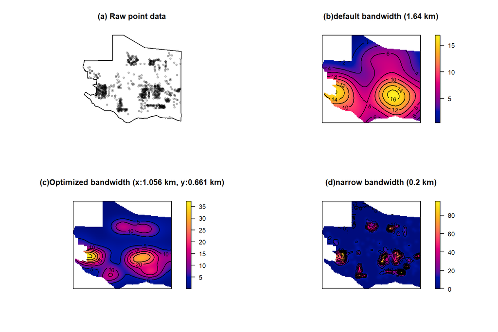

```r
#choose bandwidth based on Bowan and Azzalini / Scott's rule, the input needs to be in sp format
choose_bw <- function(spdf) {
  x <- coordinates(spdf)
  sigma <- c(sd(x[,1]),sd(x[,2])) * (2/(3*nrow(x)))^(1/6)
  return(sigma/1000)
}

#load package
library(spatstat)
library(GISTools)

#convert the data in sf format (in UTM) to sp format
pts_sp <- as(pts_utm, 'Spatial')
van_poly_sp <- as(van_poly_utm, "Spatial")

#convert the data in sp format to the formats that can be handle by the spatstat package
library(spatstat)
pts_ppp <- as(pts_sp, "ppp")
van_poly_owin <- as(van_poly_sp, "owin")

#bind the boundary to the data
Window(pts_ppp) <- van_poly_owin

#remove the marks (attributes) in the points for the codes to run (attributes are not important for KDE)
marks(pts_ppp)  <- NULL

#plot the raw data
par(mfrow=c(2,2),cex=0.7)
plot(pts_ppp, main="(a) Raw point data", cols=rgb(0,0,0,.2), pch=20)

#rescale the data to larger unit in km instead of meter
pts.km <- rescale(pts_ppp, 1000, "km")
van.km <- rescale(van_poly_owin, 1000, "km")

K1 <- density(pts.km) # Using the default bandwidth
plot(K1, main="(b)default bandwidth (1.64 km)", las=1)
contour(K1, add=TRUE)

K2 <- density(pts.km, sigma=choose_bw(pts_sp)) # Using optimized bandwidth
plot(K2, main="(c)Optimized bandwidth (x:1.056 km, y:0.661 km)", las=1)
contour(K2, add=TRUE)

K3 <- density(pts.km, sigma=0.2) # Using a narrow bandwidth
plot(K3, main="(d)narrow bandwidth (0.2 km)", las=1)
contour(K3, add=TRUE)
```

## 3.3 Explaining patterns

### 3.3.1 spatial modeling methods

# Reference

1. Caplan, J. M., Kennedy, L. W. & Neudecker, C. H. Cholera deaths in soho, london, 1854: Risk terrain modeling for epidemiological investigations. *PLOS ONE* **15**, e0230725 (2020).

2. Fortin, M. J. & Dale, M. R. T. *Spatial analysis: A guide for ecologists*. 1–365 (Cambridge University Press, 2005). doi:10.1017/CBO9780511542039.

3. Diggle, P. J. *Statistical analysis of spatial and spatio-temporal point patterns, third edition*. 1–264 (CRC Press, 2013). doi:10.1201/b15326.

4. Diggle, P. J. On parameter estimation and goodness-of-fit testing for spatial point patterns. *Biometrics* **35**, 87 (1979).

5. Brunsdon, C. & Comber, L. *Introduction to r for spatial analysis & mapping, first edition*. 175–176 (SAGE Publications Ltd, 2015).